# Презентация по лабораторной работе №6

Реализация основных моделей в подходе сетей Петри

Пакавира Арсениу Висенте Луиш

1032225105@rudn.ru

Российский университет дружбы народов

2026-09-04

# Информация

## Докладчик

- Пакавира Арсениу Висенте Луиш
- НФИбд-02-23
- кафедра математического моделирования и искусственного интелекта
- Российский университет дружбы народов им. П. Лумумбы
- 1032225105@rudn.ru

[figure not shown]

# Цель работы

Реализовать модель эпидемии SIR с использованием сетей Петри.

# Задание

1. Создать рабочий каталог для кода.
2. Установить необходимые пакеты.
3. Выполнить предложенный код.
4. Преобразовать код в литературный стиль.
5. Сгенерировать из литературного кода:
   - чистый код;
   - jupyter notebook;
   - документацию в формате Quarto.
6. Выполнить код из jupyter notebook.
7. Интегрировать документацию в формате Quarto в отчёт.
8. Добавить в код в литературном стиле вычисление для набора параметров.
9. Сгенерировать из литературного кода с параметрами:
   - чистый код;
   - jupyter notebook;
   - документацию в формате Quarto.
10. Выполнить код из jupyter notebook с параметрами.
11. Интегрировать документацию с параметрами в формате Quarto в отчёт.

# Теоретическое введение

Модель описывает переходы между тремя состояниями: - S (восприимчивые) — могут заразиться; - I (инфицированные) — заражают других и выздоравливают; - R (выздоровевшие / с иммунитетом) — больше не участвуют в эпидемии.

Сеть Петри содержит два перехода: - infection: S + I → I + I (скорость $\beta$); - recovery: I → R (скорость $\gamma$)

# Выполнение лабораторной работы

## Создание проекта

Создал новый проект с пакетом DrWatson языка julia (рис. 1).

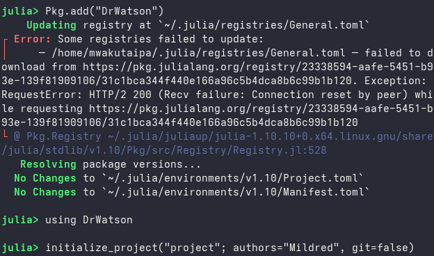

Рисунок 1: Создание проекта

## Установка пакеты

Далее я установил остальные необходимые пакеты (рис. 2)

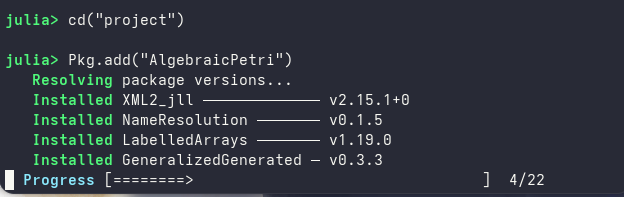

Рисунок 2: Установка пакеты

## Основная программа

Потом я выполнила предвложенный код основной программы, который реализует вычислетельную логику модели. В нем входят функции для построения сети, детерминированной и стохатической симуляции, решения ОДУ и визуализации.

## Симуляция для набора параметров

Далее я преобразовала код в литературный стиль и выполнила такой же эксперимент в ноутбуке для набора параметров но графики получились одинаковые.

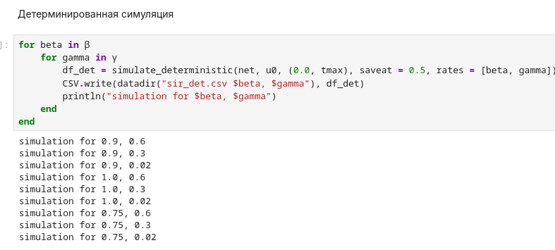

Рисунок 5: Симуляция для набора параметров